# Interpretations et explications du clustering

Chiara Coppa

12/20/2022

## Introduction

La procédure de clustering est une méthode qui permet d’unir des entités avec des caractéristiques similaires dans un même groupe. Cette opération est donc une mesure de la similarité entre ces entités. Le clustering, que j’ai utilisé, est appelé “non-supervisé” parce que je n’ai pas défini, en avance, les groupes qui doivent se former, mais ces groupes se créent sur la base des valeurs des entités. La méthode que j’ai utilisée pour réaliser le clustering est la classification ascendante hiérarchique, qui construit une hiérarchie des entités en les regroupant selon les caractéristiques. Au début, les entités sont toutes séparées et en fonction de leurs caractéristiques vont se regrouper ensemble. Se forme ainsi un dendrogramme qui illustre le regroupement des entités dans ces groupes de clusters.

## Calcul du clustering

Pour calculer le clustering dans R, il faut tout d’abord charger les données à utiliser. J’ai utilisé la commande “read.delim” et j’ai chargé les données de l’ACP (optimisée). Ensuite, comme pour le calcul de l’ACP, j’ai sélectionné les colonnes de 2 à 9, pour prendre en considération seulement les indicateurs (et pas le nom des communes).

Pour le calcul des clusters avec la classification ascendante hiérarchique, il faut tout d’abord créer une matrice des distances, qui sert ensuite pour le calcul de la classification ascendante hiérarchique (CAH). Dans ce cas, j’ai utilisé la distance euclidienne. Puis j’ai calculé la CAH selon la méthode de Ward, qui se base sur la variance. Elle considère la variance entre les entités et elle décide de réunir les entités qui possèdent une variance mineur et de séparer celles qui ont entre eux une variance majeure.

Une fois calculés les clusters, j’ai visualisé la procédure de regroupement en réalisant le dendrogramme (avec le code “plot”). À partir du dendrogramme, j’ai décidé de couper le regroupement à une hauteur de 0,6, où la distance entre les groupes était importante. Ceci m’a permis de déterminer 4 classes. À l’aide de “cutree” j’ai donc partitionné les entités en quatre clusters et avec “table” j’ai identifié la position des 4 clusters dans le dendrogramme. Le cluster numéro 1 possède huit entités donc se positionne dans le dendrogramme à la deuxième position, le cluster numéro 2 avec 5 communes se trouve à la première position, le cluster numéro 3 avec 14 communes est en dernière position et le cluster numéro 4 avec 4 communes se trouve en troisième position. Toujours avec “write.table” j’ai exporté un tableau avec les communes et les clusters dans lesquels les communes ont été classifiées.

### Analyse exploratoire

Pour interpréter les différents clusters, j’ai effectué une analyse exploratoire des données en fonction des clusters, pour comprendre quels clusters possèdent quelles caractéristiques. J’ai décidé de charger dans R la densité de la population des communes pour avoir un indicateur de la typologie des communes (si plus rurales ou plus urbaines). Puis, j’ai ajouté la classification dans les 4 clusters et cette variable de densité au tableau initiale des indicateurs. Ensuite, j’ai calculé, en fonction des clusters, la moyenne de certaines variables plus significatives de cette région, à l’aide de la commande “aggregate”.

J’ai calculé tout d’abord la moyenne de la proportion de surface agricole pour les communes divisées selon les cluster et ce calcul m’a donné des valeurs majeures pour les clusters 2 et 3. Je peux déjà considérer que les clusters 2 et 3 se réfèrent aux communes plus rurales. Ensuite, j’ai calculé la moyenne aussi pour le secteur primaire. Dans ce cas, aussi j’ai eu des valeurs plus élevées dans les clusters 2 et 3. La théorie de la ruralité des clusters 2 et 3 se renforce. Puis, j’ai calculé la moyenne de la densité et j’ai trouvé que les clusters 1 et 4 ont une densité majeure, signe d’une plus grande urbanisation. Enfin, j’ai calculé aussi la proportion du secteur tertiaire et j’ai trouvé qu’il est plus présent dans les clusters 1 et 4. Cette analyse m’a donc amené à considérer les clusters 2 et 3 comme des clusters plus rurales tandis que les clusters 1 et 4 comme étant urbaines. En regardant plus soigneusement les données, j’ai pu aussi identifier entre les deux clusters rurales lequel est plus rurale. J’ai trouvé que le cluster 2 est moins rural que le cluster 3. La même opération, je l’ai faite avec les deux clusters plus urbains. J’ai trouvé que le cluster 1 est plus urbain que le 4.

À l’aide des graphiques “plot_ly” j’ai mis en évidence les caractéristiques principales pour chaque cluster:

Cluster 1: rouge

- communes avec moins de surface agricole
- proportion de population âgée faible (peu de 65+)
- communes avec moins de secteur primaire
- commune avec plus de secteur tertiaire
- commune avec densité majeure

Cluster 2: vert

- communes avec une grande surface agricole
- communes avec une population beaucoup plus jeune (moins de 65+)
- secteur primaire présente
- secteur tertiaire faible
- densité faible

- communes avec plus de surface agricole
- communes avec une population beaucoup plus âgée (65+)
- communes avec plus de secteur primaire
- secteur tertiaire faible
- densité assez faible

- communes avec moins de surface agricole par rapport aux autres
- communes avec une population assez âgée (65+)
- secteur primaire faible
- secteur tertiaire plus important
- densité assez élevée

Enfin, j’ai classifié mes clusters de la manière suivante:

- 1: Région urbaine avec un secteur tertiaire développé et une population jeune (8 communes)
- 2: Région rurale avec une population jeune (5 communes)
- 3: Région rurale avec un secteur primaire développé et une population âgée (14 communes)
- 4: Région d’agglomération avec une population assez âgée (4 communes)

## Carte des clustres

Après avoir identifié les clusters, je les ai cartographiés sur une carte choroplèthe pour voir la spatialité du phénomène. La carte qui en résulte est la suivante:

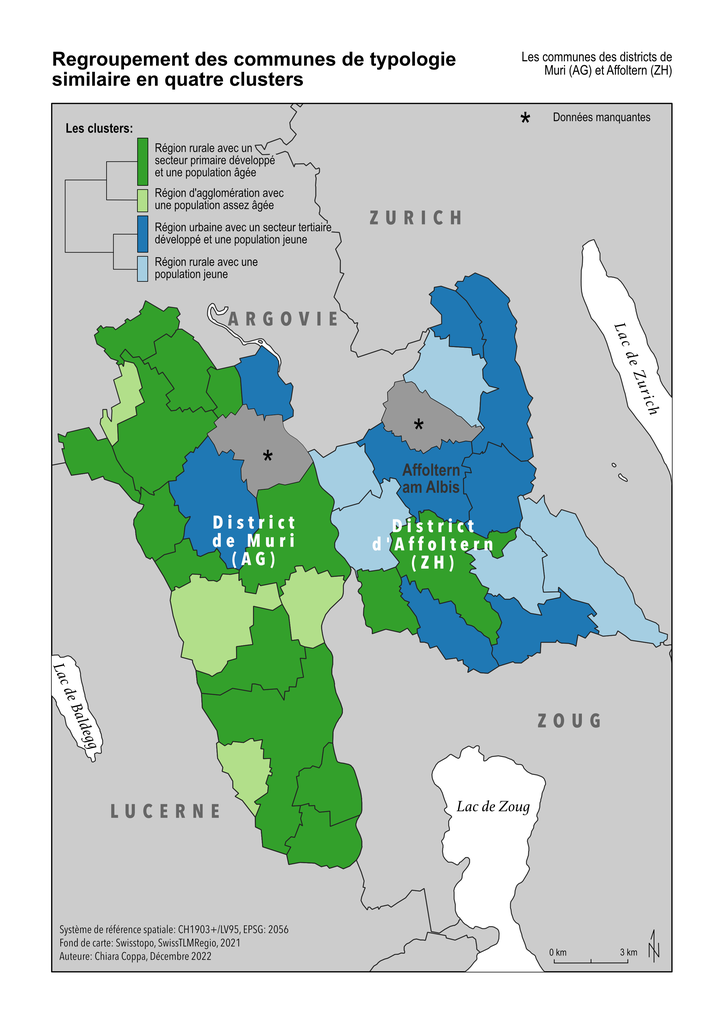

## Conclusion

J’ai classifié les communes en quatre groupes à l’aide d’une classification hiérarchique ascendante et je les ai interprétés et nommés. En cartographiant les clusters, j’ai pu à nouveau constater que le district de Muri est plus rural que le district d’Affoltern, mais aussi qu’il y a plus de centres urbains selon cette classification par rapport à la typologie des communes données par l’Office fédéral statistique suisse, qui donne comme commune urbaine seulement celui d’Affoltern am Albis. Cette procédure m’a donc permis de classifier les communes des districts de Muri et Affoltern, dans les quatre catégories précédemment indiquées, en se basant sur les composantes principales qui décrivent de manière plus optimale mes communes.